# RESQUE Research Profile

**This document summarizes the research style of Felix Schönbrodt - the *'fingerprint' of how research is conducted*, when only the best work is submitted to this analysis.**

**Warning**

This is a preview which shows some visual summaries - not all indicators have been covered yet, and things might change substantially.

Some parts of this profile are purely descriptive. For example, it is summarized whether researchers focus on lab or field studies, whether they predominantly work with psychophysiological data or rather focus on questionnaire studies.

Other parts contain, to some extent, a normative aspect: For example, research that is reproducible, which allows independent auditing because it provides open data and scripts is, *ceteris paribus*, better than research that does not have these aspects. Research outputs with these objective quality criteria of methodological rigor can gain 'bonus points' which are summed across all provided research outputs and contribute to the Rigor Profile Overview.

**Is the rigor score systematically biased against certain fields (e.g., fields where open data is difficult)?**

We took care not to systematically disadvantage certain fields or research styles. Generally, the rigor score is a relative score, computed as 'percentage of maximal points' (POMP) score across all indicators that are applicable. For any indicator, one can choose the option 'not applicable' if an indicator *principally* cannot be attained by a research output. The points of such non-applicable indicators are removed from the maximum points and therefore do not lower the computed relative rigor score. However, in order to prevent gaming of this scheme, any 'not applicable' claim needs to be justified. Only when the justification is accepted by the committee, the point is removed. With no or insufficient justification, in contrast, the indicator is set to 'not available' (=0 points) and the maximum points are not adjusted.

## Submitted research outputs

9 research outputs have been submitted. The following table shows the types of submitted outputs, and whether they have been flagged as suitable for the rating sheet (*yes*) or not (*no*).

|  | No | Yes |
| --- | --- | --- |
| Publication | 1 | 8 |
| Data set | 0 | 0 |
| Research software | 0 | 0 |

The 9 publications had the following types:

| Var1 | Freq |
| --- | --- |
| Published Paper | 9 |

And the following methodological type:

| Type of method | # papers |
| --- | --- |
| Empirical | 3 |
| Meta Analysis | 3 |
| Other Method | 2 |
| Simulation | 4 |
| Theoretical | 2 |

### Team science in publications?

9 out of 9 submitted publications could be automatically retrieved with openAlex.

| Team category | Frequency | % |
| --- | --- | --- |
| Single authored | 0 | 0% |
| Small team (<= 5 co-authors) | 7 | 78% |
| Large team (6-15 co-authors) | 0 | 0% |
| Big Team (> 15 co-authors) | 2 | 22% |

## Contributorship profile (CRediT roles)

Based on 9 submitted publications, this is the self-reported contributorship profile:

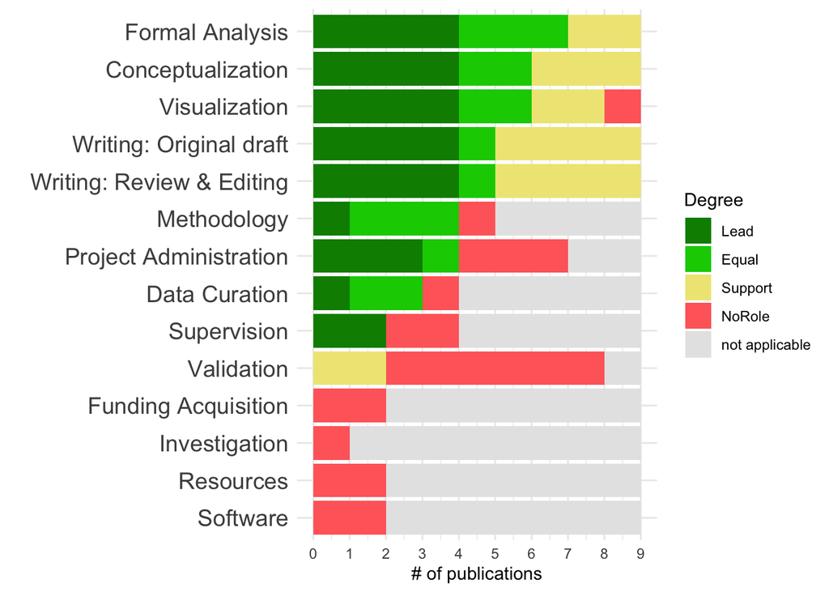

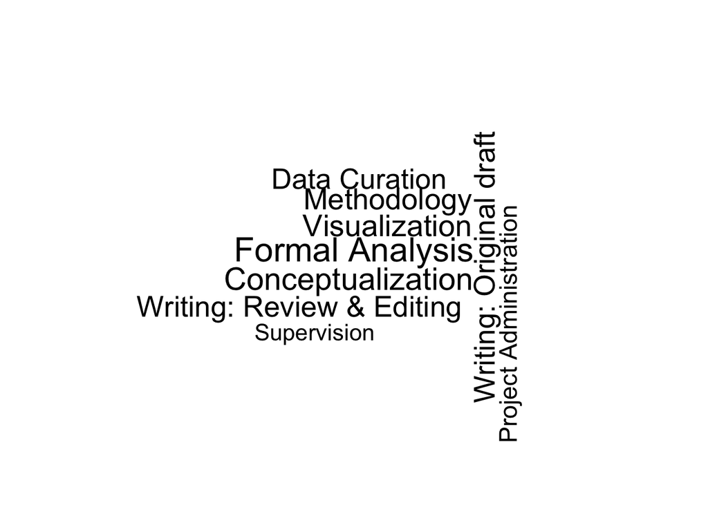

We categorized papers into levels of involvement, based on the degrees of contributorship:

| Involvement.Level | Definition | Publications |
| --- | --- | --- |
| Very High | (>=3 roles as *lead*) OR (>= 5 roles as (*lead* OR *equal*)) | 5 |
| High | (1-2 roles as *lead*) OR (3-4 roles as *equal*) | 3 |
| Medium | (1-2 roles as *equal*) OR (>= 5 roles as *support*) | 1 |
| Low | All other combinations | 0 |

# Research impact: Highly popular publications

[BIP! Scholar](https://bip.imsi.athenarc.gr/site/home) (a non-commercial open-source service to facilitate fair researcher assessment) provides impact scores for publications. It provides **five impact classes** based on norm values:

- Top 0.01%
- Top 0.1%
- Top 1%
- Top 10%
- Average (Bottom 90%)

Here, we consider the **Popularity** measure.

**Computation of the Popularity metric**

This indicator reflects impact/attention of an article in the research community at large. It is based on *AttRank*, a variation of PageRank (known from the Google search algorithm) that accounts for the temporal evolution of the citation network. By that, it alleviates the bias against younger publications, which have not had the chance to accumulate a lot of citations. It models a researcher’s preference to read papers which received a lot of attention recently. It was evaluated (and vetted) in its performance to predict the ranking of papers concerning their *future impact* (i.e., citations). For more details, see [BIP! glossary](https://bip.imsi.athenarc.gr/site/indicators) and the references therein.

From 9 submitted papers of Felix Schönbrodt, 8 were in the top 10% popularity class of all papers or better.

The highly popular papers are:

| Title | 3 year citation count | Overall citation count | Popularity | Candidates' CRediT involvement | Candidates' CRediT main roles |
| --- | --- | --- | --- | --- | --- |
| ️🌟Bayes factor design analysis: Planning for compelling evidence | 76 | 341 | Top 0.1% | Very High | **Lead:** Conceptualization, Formal Analysis, Visualization, Writing: Original draft, Writing: Review & Editing **Equal:** Methodology |
| ️🌟At what sample size do correlations stabilize? | 90 | 1230 | Top 0.1% | Very High | **Lead:** Conceptualization, Formal Analysis, Methodology, Project Administration, Visualization, Writing: Original draft, Writing: Review & Editing |
| ️✨Replicability, Robustness, and Reproducibility in Psychological Science | 165 | 165 | Top 1% | Medium | **Equal:** Data Curation, Formal Analysis |
| ️✨Correcting for Bias in Psychology: A Comparison of Meta-Analytic Methods | 111 | 272 | Top 1% | Very High | **Equal:** Conceptualization, Formal Analysis, Methodology, Project Administration, Visualization, Writing: Original draft, Writing: Review & Editing |
| Big little lies: a compendium and simulation of *p* -hacking strategies | 12 | 12 | Top 10% | High | **Lead:** Supervision **Equal:** Conceptualization, Methodology |
| Measuring Implicit Motives with the Picture Story Exercise (PSE): Databases of Expert-Coded German Stories, Pictures, and Updated Picture Norms | 18 | 18 | Top 10% | Very High | **Lead:** Conceptualization, Data Curation, Formal Analysis, Project Administration, Visualization, Writing: Original draft, Writing: Review & Editing |
| A Series of Meta-Analytic Tests of the Efficacy of Long-Term Psychoanalytic Psychotherapy | 9 | 17 | Top 10% | High | **Lead:** Supervision |
| Testing Similarity Effects with Dyadic Response Surface Analysis | 32 | 68 | Top 10% | Very High | **Lead:** Conceptualization, Formal Analysis, Project Administration, Visualization, Writing: Original draft, Writing: Review & Editing |

# Rigor profile overview

**Computation of the relative rigor score**

The relative rigor score (RRS) is computed as a 'percentage of maximal points' (POMP) score of multiple indicators. The indicators are grouped into five categories: Open Data, Preregistration, Reproducible Code & Verification, Theorizing, and Open Materials. Indicators that are flagged as 'not applicable' are removed from the maximum points and therefore do not lower the RRS.

The grey circles are norm values based on a sample of 63 papers from mostly early and mid-career researchers that submitted their three best papers, indicating the 50%, 90%, and 99% quantile of the relative rigor score.

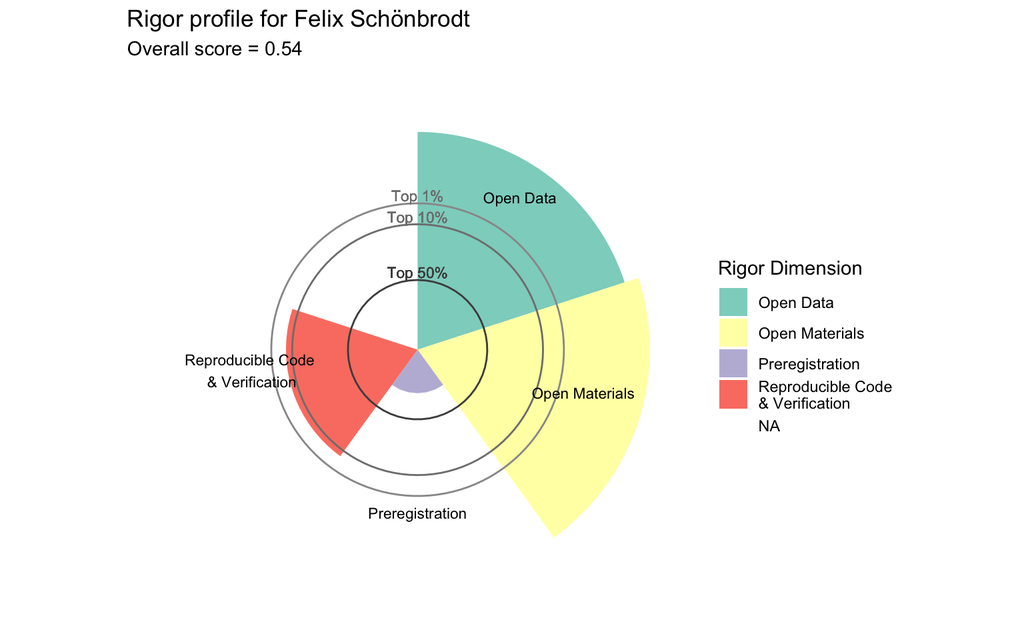

Note: For the rigor category **Theorizing**, the applicant has indicated that this category did not apply to any submitted publication.

# Open Data in Publications

# Reproducibility

## Correctness of computational results has been independently verified

3 papers had empirical data. Of these analysis have been independently verified for computational correctness:

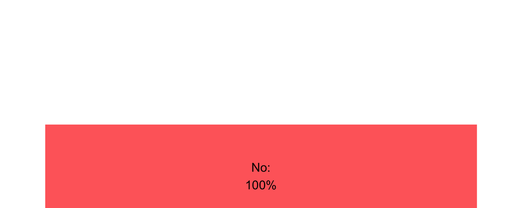

# Preregistration

## Was the research preregistered / a registered report?

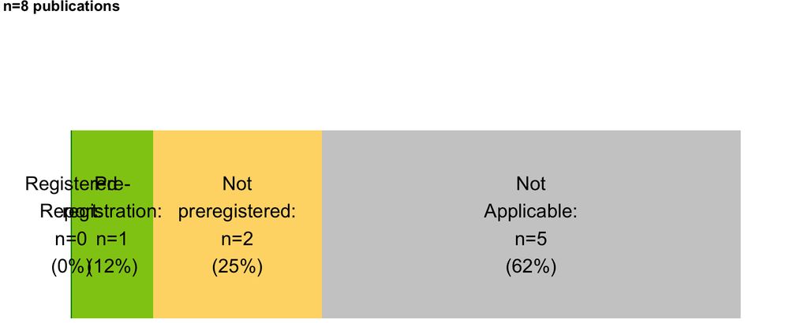

## Replication: The publication contained a preregistered replication attempt (either direct/close or conceptual)

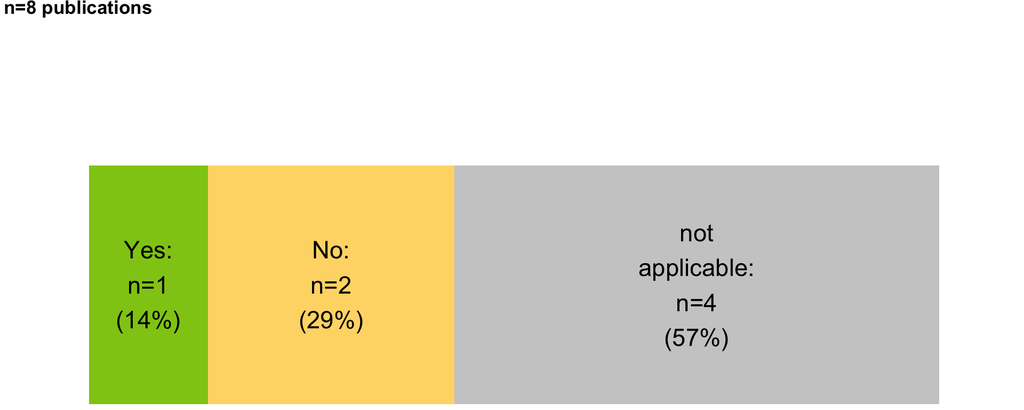

**The following publications contained preregistered replications:**

| TitleLink | Year |
| --- | --- |
| A Series of Meta-Analytic Tests of the Efficacy of Long-Term Psychoanalytic Psychotherapy | 2020 |

## What has been preregistered?

1 of 8 eligible publications had preregistrations. The following components have been preregistered (relative to 1 preregistrations):

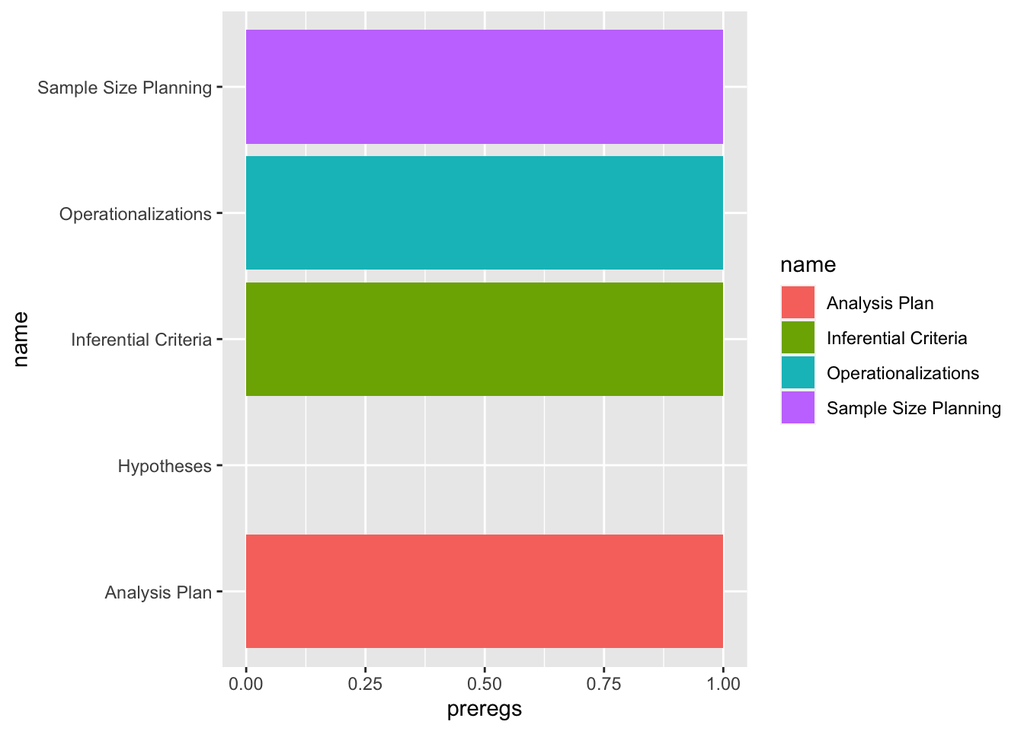

# 'Not applicable' justifications

Choosing 'not applicable' indicates that an indicator *principally* cannot be attained by a research output. To avoid bias against certain research fields, the points of such non-applicable indicators are removed from the maximum points and therefore do not lower the computed relative rigor score. However, in order to prevent gaming of this scheme, any 'not applicable' claim needs to be justified. Only when the justification is accepted by the committee, the point is removed. With no or insufficent justification, in contrast, the indicator is set to 'not available' (=0 points) and the maximum points are not adjusted.

These are all claims of non-applicability from this applicant:

### P_Preregistration

| Title | Year | P_Preregistration | P_Preregistration_NAExplanation |
| --- | --- | --- | --- |
| Machine Learning and Risk Assessment: Random Forest Does Not Outperform Logistic Regression in the Prediction of Sexual Recidivism | 2023 | NotApplicable |  |
| Big little lies: a compendium and simulation of *p* -hacking strategies | 2023 | NotApplicable | Purely exploratory work |
| Correcting for Bias in Psychology: A Comparison of Meta-Analytic Methods | 2019 | NotApplicable | Exploratory simulation study |
| Bayes factor design analysis: Planning for compelling evidence | 2017 | NotApplicable | Exploratory simulation |
| At what sample size do correlations stabilize? | 2013 | NotApplicable | Exploratory simulation |

### P_FormalModeling

| Title | Year | P_FormalModeling | P_FormalModeling_NAExplanation |
| --- | --- | --- | --- |
| Machine Learning and Risk Assessment: Random Forest Does Not Outperform Logistic Regression in the Prediction of Sexual Recidivism | 2023 | NotApplicable | Purely exploratory / data driven research |
| A Series of Meta-Analytic Tests of the Efficacy of Long-Term Psychoanalytic Psychotherapy | 2020 | NotApplicable | Meta-analysis - no theory involved. |
| Correcting for Bias in Psychology: A Comparison of Meta-Analytic Methods | 2019 | NotApplicable | Exploratory simulation study |
| Bayes factor design analysis: Planning for compelling evidence | 2017 | NotApplicable | Exploratory simulation |
| At what sample size do correlations stabilize? | 2013 | NotApplicable | Exploratory simulation |

### P_Data_Open

| Title | Year | P_Data_Open | P_Data_Open_NAExplanation |
| --- | --- | --- | --- |
| Replicability, Robustness, and Reproducibility in Psychological Science | 2022 | NotApplicable | Proprietary company data, was not allowed to upload. |

### P_OpenMaterials

| Title | Year | P_OpenMaterials | P_OpenMaterials_NAExplanation |
| --- | --- | --- | --- |
| Big little lies: a compendium and simulation of *p* -hacking strategies | 2023 | NotApplicable | Everything is contained in the source code. |
| Replicability, Robustness, and Reproducibility in Psychological Science | 2022 | NotApplicable | No material was used, other than the data itself. |

### P_PreregisteredReplication

| Title | Year | P_PreregisteredReplication | P_PreregisteredReplication_NAExplanation |
| --- | --- | --- | --- |
| Replicability, Robustness, and Reproducibility in Psychological Science | 2022 | NotApplicable | The first analysis of its kind - no replication possible. |
| Correcting for Bias in Psychology: A Comparison of Meta-Analytic Methods | 2019 | NotApplicable | Exploratory simulation study |
| Bayes factor design analysis: Planning for compelling evidence | 2017 | NotApplicable | Exploratory simulation |
| At what sample size do correlations stabilize? | 2013 | NotApplicable | Exploratory simulation |

### ‘This output is generally not suitable for the assessment scheme’

| Title | Year | P_Suitable | P_Suitable_Explanation |
| --- | --- | --- | --- |
| Testing Similarity Effects with Dyadic Response Surface Analysis | 2018 | No | Purely conceptual/methodological/tutorial paper, without simulations |